# Japanese Grand Prix Fantasy League Report

こんにちは、管理者 and welcome to the race report for the 2025 Formula 1 Japanese Grand Prix, and the Fantasy League report, of course. The Japanese Grand Prix is a long stay on the calendar, and one of the most iconic circuits in F1 history. It is the only true figure of eight circuit on the calendar, it is a combination of twisty high-speed corners, fast 90-degree turns, a banked hairpin, and top speed sections. Who can forget some of the iconic images of Alonso going around the outside of Schumacher into 130R, or Senna and Prost coming together at the first, and last, corners, or perhaps you remember the somber day in 2014 when F1 last suffered a fatality. Whatever your memories of the Suzuka circuit are, the Japanese Grand Prix usually throws up some chaos and action. Did we get any this year? Let's find out.

## The News

### Musical Chairs

Red Bull's decision to replace Liam Lawson with Yuki Tsunoda from the Japanese Grand Prix onwards, following a difficult start to the 2025 season for the rookie, raises questions about the team's driver management strategy. Lawson's initial struggles might warrant a change, but it is worth recalling his promising Silverstone test last year, where his lap times reportedly matched those of Verstappen. This, coupled with strong performances deputizing for Ricciardo, led to his possibly premature promotion to replace Perez for 2025. However, Lawson's first two race were undeniably challenging, culminating in a double last-place qualifying in China and a Q1 exit with a retirement in Australia. This prompted a swift decision to bring in Tsunoda, a driver many felt was deserving of the seat in the first place. Now in his fifth season, Tsunoda's past has been marked with inconsistency, but his impressive 2024 season suggests a potential step forward in maturity and performance.

The rapid driver change, however, highlights a more systemic issue with Red Bull, dating back to Max Verstappen's arrival at Toro Rosso in 2015. Verstappen's exceptional talent quickly became apparent, leading to his promotion to the senior team in 2016, replacing Kvyat and winning on debut. Since then, Red Bull's focus has understandably gravitated towards building a car that maximizes Verstappen's potential. This emphasis, while yielding significant success, created a challenging environment for his teammates. Even experienced drivers like Ricciardo struggled alongside the Dutchman, eventually leading to Ricciardo's departure. Subsequent junior drivers like Gasly and Albon also struggled with the car's handling, often resulting in costly accidents and inconsistencies. This pattern forced Red Bull to look outside their academy, where they found Sergio Perez.

Perez played a crucial role in Verstappen's 2021 championship, and achieved notable successes in 2022, but his performance began to decline. The car, described by former Red Bull driver Albon as having a "sensitivity issue" that Verstappen could manage, seemed to exacerbate Perez's difficulties. A string of qualifying struggles, race incidents, and costly repairs ultimately overshadowed his contributions, and Perez was eventually replaced by Lawson. Red Bull's approach to driver changes raises concerns about the team becoming overly reliant on Verstappen's unique driving style, potentially hindering the performance of any other driver in the second seat. This situation risks mirroring the struggles Honda faced when their entire development was geared towards Marc Marquez, potentially leading to a difficult period of adjustment should Max ever leave. While Tsunoda's opportunity is well-deserved, the underlying question remains whether he can overcome the challenges that have plagued Max's recent teammates.

### Perez Is Back

No, you read that correctly, Sergio Perez has hinted he may make a return to F1 sooner than we think. Though, to be fair, we thought he would never return. The exit Perez suffered from the sport, leaving his contract 2 years earlier than had been agreed, so late in the season, left the Mexican man with no options for 2025. Sergio has spent most of 2025 back home with his family, but has reported that he will consider a return in 2026 if the project "makes sense", whatever that means. At 35 years old, Sergio is relying on his years of experience and variety in the grid to be his redeeming feature, not expecting to be in the sport for much longer; hence, he will need to find a team who want an experienced hand to build them up, rather than take them into the future. I suspect someone like Cadillac (GM) or perhaps Audi will be interested in an experienced hand to guide them into the sport.

### Opmeer Back On Top

Jarno Opmeer is a name that may only be familiar to a select few of you, but the former racing driver was crowned F1 Sim Racing Drivers' World Champion for a record third time last week with an absolutely cracking season finale in Abu Dhabi. For those who don't follow the Sim Racing series, they typically follow the F1 calendar, but condense their events into 3-4 days of intense racing. Warm-up, qualifying, and race sessions are condensed into a day, with a 50% race distance. The competition is fierce, with races often finishing with every driver within DRS range of the car in front, the margins are so tight that one minor mistake can cost you 5 places. Opmeer, who races for the Red Bull sim academy, was the championship leader going into the race, ahead of Kick F1 Sim Racing Team's Thomas Ronhaar, and Williams Esports' Ismael Fahssi. The race was a true nail biter, with multiple race leaders, wild strategies, collisions between the championship contenders, and Ronhaar showing his dirty racing craft at full chat. In the final moments of the race, Ronhaar received a handful of penalties for multiple collisions, demoting him out of the points and handing the championship (and constructors' championship) to Opmeer and Red Bull. Opmeer, formerly a Formula Renault F4, Eurocup, and Formula Renault driver, almost made it to the F1 scene in 2017 but found that the competition was too fierce to make it into F2. Since then, he has turned his hand to Sim Racing and found success with Alfa Romeo, Mercedes, and Red Bull to become the most successful driver the series has ever seen. Long may it continue, the sim racing series is a refreshing interlude in the off-weeks.

### The Podcast

Some of you may have seen the announcement in the last few days that I am starting a podcast. The podcast revolves around the wider world of motorsport, featuring discussions about F1, Moto GP, WEC, and much more. My co-host Tim and I would like to keep you in the loop about future updates, so please go ahead and find us on Instagram, or get in touch if you want to know more. Watch this space!

## Grand Prix Report

The biggest story from free practice was the massive, nearly 200 mph, crash at turn 1 for Jack Doohan. The Alpine rookie approached the first corner in free practice 2 in full attack mode, left his DRS open and lost all control of the car, which span into the barrier causing a huge amount of damage. Jack walked away from the crash, declaring himself okay over the radio before being sent for medical checks. Suzuka is an odd layout with the DRS, since under normal circumstances your DRS would deactivate under braking, but at the double-apex first corner of Suzuka, you don't brake until halfway through the first right hand corner. As such, drivers either have to manually press the DRS button to shut the rear-wing flap, or mildly tap the brake pedal to deactivate. Alpine reported that Jack "misjudged" his approach to turn 1. The estimated cost of the damage is around $1.5 million, which is significant in a cost cap era, only three races into the season. Jack can't afford many more mistakes with Franco Colapinto waiting in the wings, with the Aussie rumoured to have 5 races at the start of the season to prove that Alpine made the right decision.

### Qualifying Report

On to qualifying then, and there's no surprise that this is where most of the action for the weekend took place. Despite reporting handling issues all weekend, reigning champion Max Verstappen was on the pace of the McLarens in Q1. Hamilton was the only driver on mediums in Q1, with the Brit maybe looking to run in a set of mediums for the race, just to take that shine off the tyres for some extra grip off the line. Oscar Piastri was the early pace setter, with Mercedes also looking strong; their car through the flat out sections looked unreal, the former champions have clearly put their ground effect troubles behind them this year. Perhaps the most notable story from Q1 was the troubles down at Racing Bulls, and no it wasn't for Liam Lawson. Isack Hadjar reported that he couldn't focus, saying the car was not drivable, and seemed to be distracted by something in his seat. Despite the obvious pain to his gentleman's area, the rookie made it through Q1 and could make adjustments in the break. Your Q1 eliminations were Nico Hulkenberg, Gabriel Bortoleto, Esteban Ocon, Jack Doohan, and Lance Stroll. That's quite surprising from Stroll, who has so far put in a decent performance this year. Similarly surprised by relative-veteran of the sport Esteban Ocon, who was out-qualified by his rookie teammate.

Onto Q2 now, and the first appearance in a Q2 session in 2025 for Liam Lawson, who made it in by 0.016 seconds ahead of Nico Hulkenberg, the German dipping a wheel in the gravel on his last push lap. Reigning champion Verstappen was first out on track, with the top teams running brand new tyres from the outset. Norris beat him to the top, with Russell slotting in second in the early laps. After the first laps were complete, a small fire broke out in the grass, a problem that had plagued Suzuka all weekend long and is something that I wasn't going to really comment on, because they should do better in the pinnacle of motorsport. You know what, no, I am going to rant about this. Formula 1 is supposed to be the ultimate motorsport series on the planet, it is filled with technology years ahead of what regular consumers like you and I could ever get ahold of, and yet, they can't fix track limits, they can't fix side-by-side racing, and they can't stop a titanium skid block under the cars from starting small grass fires by the side of the track. Why was the grass so dry that a small spark could set it ablaze? Why not put gravel on the outside of the track so that there is a gap between something that could be highly flammable and something which can start a fire? It makes no sense. Anyway, once the red flag period had ended, all the drivers came back out to fight for that spot in Q3. The Ferraris were first out on track, electing to do two push laps. It was close at the top but even closer around the elimination zone, with drivers like Alonso and Gasly pushed out in the last set of laps. Why was it important that the Ferraris did two push laps? Well Sainz was the last driver to complete his push lap just before the chequered flag fell, and so he assumed he was the last driver. But he wasn't. Lewis Hamilton crossed the line to start a push lap just before the flag came out, and the Brit flew into turn 1 to be met by a slow-moving unaware Williams on the apex. The Spaniard was handed a 3-place grid penalty after qualifying. Eliminated drivers were Pierre Gasly, Carlos Sainz, Fernando Alonso, Liam Lawson, and Yuki Tsunoda. The new Red Bull man may have been beaten by the man he replaced, but let's be fair to him here, that's still the highest qualifying that second Red Bull car has seen all season, and that's one of the lowest qualifying positions the second Racing Bull has seen all season - I call that a win for Yuki.

So onto Q3 and the question really was, which McLaren would take pole? They had been quick all weekend, seemingly unchallenged by anyone around them, Mercedes were close but not close enough and Ferrari seemed a little off the pace. Their main rival, Verstappen, had been complaining about handling issues all weekend, and seemed to not quite have enough for pole. Or so we thought. In the first laps, it was advantage Max, until Oscar Piastri set a lap 2-tenths faster, demonstrating the pace in that McLaren. Leclerc slotted into third and Russell fourth, with championship leader Norris fluffing his lap and only scraping fifth ahead of Hamilton. George Russell messed up his final lap right at the beginning, into turn 1, with the Mercedes man looking like he might have made it onto the front row at least. Fellow Brit, Lando Norris, had no such trouble and even scraped the wall at the final corner to put his McLaren on pole. But you can never count out the flying Dutchman, who put in perhaps one of his best qualifying performances ever, to beat Norris by one-hundredth of a second. I know that's saying a lot, because Max had that great lap that never was in Saudi, a great lap in Monaco, and has put together some truly stunning qualifying laps, but seriously, go watch it. Piastri lined up in third, ahead of Charles Leclerc, George Russell, Kimi Antonelli (who is putting in a great first season), Isack Hadjar, Lewis Hamilton, Alex Albon, and Oliver Bearman who managed to scrape that Haas into the top ten, what a result for the young Brit.

### Race Report

So remember, from qualifying it was Verstappen, Norris, Piastri, Leclerc, Russell, Antonelli, Hadjar, Hamilton, Albon, Bearman. So, a crazy old school circuit like Japan, usually some weather to contend with? We even got some rain in the morning before the race, surely it was going to be chaos. Verstappen vs the McLarens, the Ferraris vs the Mercs, a couple of outliers in there too, I can feel the tension building for a great race. The race finished Verstappen, Norris, Piastri, Leclerc, Russell, Antonelli, Hamilton, Hadjar, Albon, Bearman. So the only overtake in the top ten was Hamilton on Hadjar. So what? You might say, so what if the top ten didn't move around much? I bet there was action with the lower teams. The next ten from qualifying was Gasly, Sainz, Alonso, Lawson, Tsunoda, Hulkenberg, Bortoleto, Ocon, Doohan, and Stroll. They finished Alonso, Tsunoda, Gasly, Sainz, Doohan, Hulkenberg, Lawson, Ocon, Bortoleto, and Stroll. So essentially, Doohan had a reasonable race, Alonso had a reasonable race, Sainz had a penalty, and Tsunoda made up a couple of places. In total, there were 18 overtakes, which is the same as the 2024 Monaco Grand Prix. Tsunoda and Hamilton had both made their moves by lap 6, getting passed Lawson and Hadjar, and there were a couple of tyre-related scraps up and down the field, but nothing major to note throughout the race. So that means we can focus on some of the stories, and make comments about the teams, and the track, rather than focus on a classic race report.

McLaren need to make changes to the way they approach races now that they have the fastest car. Yes, I am aware Max won the race, but that doesn't mean that Red Bull is particularly quick, and it definitely doesn't mean it is quicker than the McLaren. I understand that it is far too early in the season to pick a driver they want to back for the world championship, but they need to be willing to make moves. Oscar Piastri pitted first out of the top three, at a track where the undercut was not the answer, as tyre warm up was an issue. However, this did force Max's hand a little, and a few laps later he had to pit. But instead of leaving Norris out to try a different strategy (and by the way, we saw that work for Antonelli, who became the youngest driver ever to set a fastest lap), they pitted Lando directly behind Verstappen. They were unwilling to try anything to take it to the Dutchman. Now yes, Verstappen had a slow stop, and yes Norris did nearly jump him anyway, but they could have tried something. Even when Piastri caught back up to Lando and Max and showed he was faster, they didn't even try. The worst they could have done was second and third, but they could have got a first and third, or maybe a first and second. They need to try something if they are going to win the Drivers' Championship this year, because it is a bit embarrassing to win the Constructors' Championship two years running and not the Drivers'. A brief moment to talk about that incident on pit exit: it was a worthy try by Lando, and something that anyone else would have done. I am, however, a bit sick of seeing Lando fans claiming Max tried to kill him. He didn't. He didn't even really move over at all. It was all fair.

A stonking performance for Kimi Antonelli this weekend, consistent pace throughout, matching his more experienced teammate, putting in the laps required to try the alternate strategy, didn't work out for them in the end, but at least he tried something. He beats Verstappen to be the youngest ever fastest lap setter. Other rookies worth noting are Isack Hadjar, who scores his first points with Racing Bulls in eighth place, and Oliver Bearman who secured a point ahead of his far more experienced teammate.

Has the Japanese Grand Prix outgrown modern formula 1? Perhaps. Is this a problem we are going to see throughout the season? Yes probably. Here's my thoughts on this. F1 has become a series where the teams are trying to build the ultimate car, and in doing so, they sacrifice the car behind them by creating copious amounts of dirty air. These new regulations were designed to stop that, and indeed we saw it in 2022 when the regulations first launched. As has become the case with just about every regulation change, the teams have found a way to increase their dirty air, and make it harder for cars to follow and overtake. On top of that, many tracks incorporate fast sweeping corners and tight chicanes, with very little opportunity to beat someone on the brakes, or follow closely into a hard braking zone. We've seen this with the Spanish Grand Prix recently, and now we are seeing it with Japan. The problem gets worse when we get to these older circuits, because they were designed with much slower cars in mind, meaning corners like 130R were not flat out, and sector 1 was not flat out. But, there's another era of tracks for which this is a problem, and that is the Tilke era, where tracks like Abu Dhabi, Mexico, and the like are mostly sweeping fast corners, because they thought that it would be impressive to see cars flat out in corners, when what we really need is hard braking zones where drivers can attempt an overtake. Street circuits typically provide a slower environment for drivers to try and make the difference, but since the cars are 5 meters long and 2 meters wide, there's no chance that overtaking can happen at a lot of these street circuits. Hopefully the new regulations change this, but really we just need slightly slower, smaller cars, with less aero components, where the driver can really make the difference, but the teams will never go for it, because they want to prove themselves too.

## Fantasy League Scores

Scores for drivers/constructors in the current year's fantasy league, along with manager/team points, values, and statistics. Note: driver and constructor values are taken as the cost to enter the current race and are updated the week before the race.

## Lineup Scores

With not much overtaking during the race, the points scored this weekend are quite low, and of course, we now have our first set of inactive tokens, so that's been quite fun to deal with. For those who don't know, inactive tokens score -25 for each race weekend. Since this year, we have tokens for Yuki Tsunoda and Liam Lawson that are no longer in use - because they didn't just swap them in the fantasy league - I have had to change their nomenclature. Tsunoda RB and Lawson RBR represent the tokens for Yuki Tsunoda at Racing Bulls and Liam Lawson at Red Bull Racing. Tsunoda and Lawson represent the current tokens.

Max Verstappen is our winner this week, qualifying on pole and converting it to a victory, the Dutchman brings home his first win of the season with 36 points. He's followed by the two McLaren boys of Lando Norris and Oscar Piastri, with 27 and 24 points, respectively. Kimi Antonelli is a close fourth with 23 points, thanks to that fastest lap he set, and Charles Leclerc rounds out the top five with 20 points, some much needed points back on the board for the Ferrari man there. Liam Lawson was our worst driver of the week, only managing -4 points in his first reappearance at Racing Bulls. He's followed by Gabriel Bortoleto who had a pretty anonymous weekend, bringing home -2 points. Pierre Gasly next and he scores 0 this week, another tough weekend down at Alpine. Nico Hulkenberg and Esteban Ocon bring home a pair of 1s, and Lance Stroll rounds out the bottom five with 2 points.

McLaren spend another week at the top of the constructors' weekly standings with 71 points. Mercedes and Ferrari are tied for second this week, the two former rivals securing 56 points each, ahead of Red Bull in third place with 46 points. Kick Sauber have a pointless weekend in Japan at the bottom of the table, behind Alpine and Aston Martin with a pair of 9s. Haas round out the bottom three with 10 points, though not through lack of trying as Bearman put in a great weekend.

Lando Norris is comfortable at the top of the Drivers' standings at the moment, the McLaren man is the only driver in triple figures with 127 points. A strong weekend for Max, sees the gap shrink, but the Dutchman is a distant second with 95 points. Kimi Antonelli is having a great rookie season in third with 84 points, ahead of Oscar Piastri and George Russell with 79 and 78 points to round out the top five. Fernando Alonso is having a nightmare start to the season with -32 points, he's actually still behind Liam Lawson's inactive token at the moment. Gabriel Bortoleto next with -13 points, followed by Gasly and Sainz with -7 points each. Liam Lawson is in fourth with -4 points, and Jack Doohan rounds out the bottom five with -3 points.

McLaren stretch their legs at the top of the Constructors' championship, the reigning champions having 243 points to their name. Mercedes are their nearest challengers at the moment with 192 points. Red Bull round out the top three with 132 points. Alpine are at the bottom of the standings still, the French outfit the only team to be on negative points with -11. Aston Martin continue their poor season with 14 points, just behind Kick Sauber who round out the bottom three with 15 points.

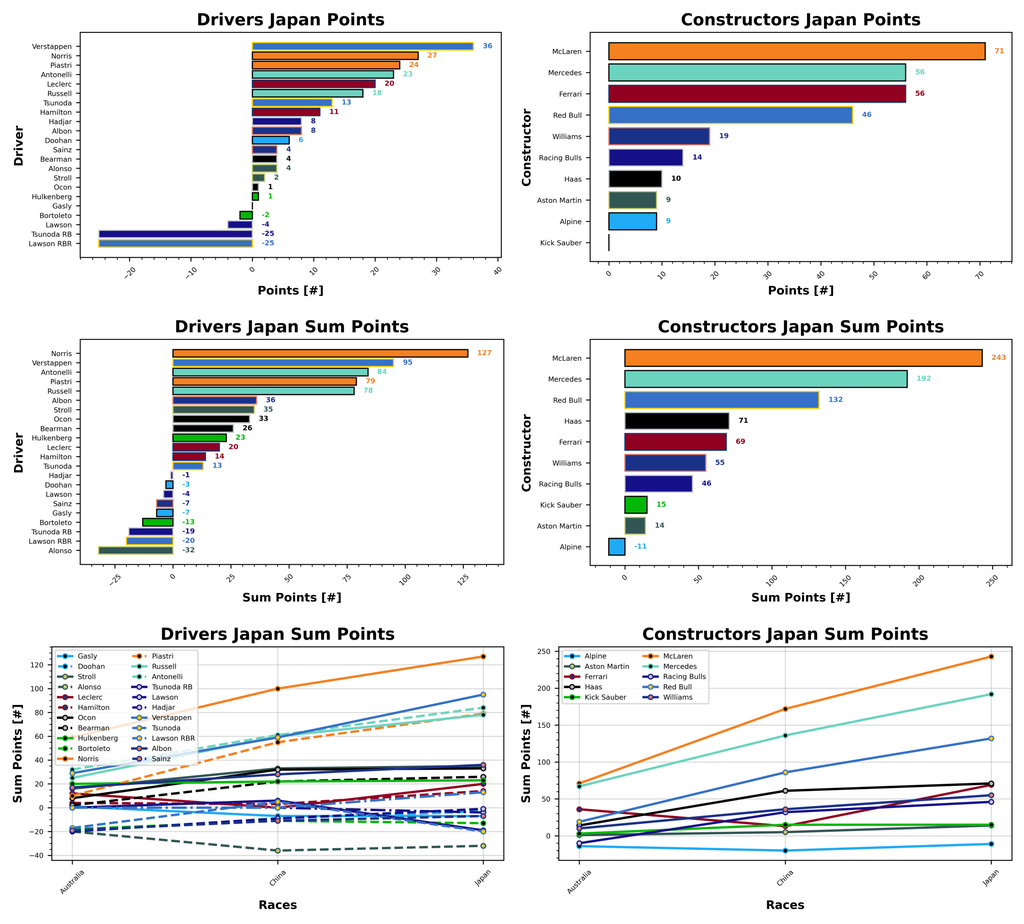

The driver market is quite volatile at the moment, but Lando Norris is still your most expensive option at the moment, worth $29.6. He's a full $1 higher than Max Verstappen ($28.6). The Ferrari boys next, with Leclerc valued higher than his more experienced teammate, with a value of $25.3 to Lewis' $23.6. Oscar Piastri is the fifth most expensive token with a value of $23.0. These are values for Japan. Bortoleto represents your cheapest option with a value of $4.8, followed by Hadjar, Doohan, Bearman, and Alonso/Hulkenberg with values of $5.0, $6.0, $6.7, and $7.6.

McLaren increase their value again this week, now sitting at $30.6 ahead of Ferrari and Red Bull, with values of $27.1 and $25.4. Kick Sauber are your cheapest constructor with a value of $6.2. Aston Martin next with a value of $7.3 and then Racing Bulls with a value of $8.0.

All values are in $M.

Lawson replaces Alonso as the worst performing driver of the season, although to be fair to the Kiwi he has only 1 race to be considered for there. We are now starting to see a clear breakaway for some of the consistent drivers in the league with a 100% positive percentage. Alpine are clearly the worst team at the moment, only managing 1 positive scoring weekend, while most teams have so far all scored positively.

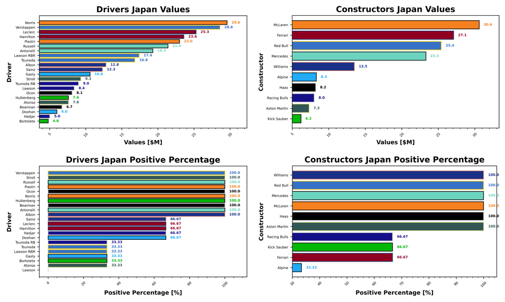

It was quite a low scoring week this week, and as such most of the averages are starting to come down. Lando sits on 42.3 points per race, ahead of Verstappen with 31.7, Antonelli with 28.0, Piastri with 26.3, and Russell with 26.0. Alonso has managed to reduce his deficit, now averaging -10.7 points per race, behind Bortoleto with -4.3 points per race, Gasly/Sainz with -2.3, Lawson with -1.3, Doohan with -1.0, and Hadjar with -0.3 points per race.

The Average Points table obviously mirrors that of the total points table, but McLaren are currently averaging 81 points per race, coming down a little from last week, ahead of Mercedes with 64 and Red Bull with 44 points per race. Interestingly, Red Bull is the only one of those three to increase their average points this week - a sign that they made the right decision with Yuki? Alpine put in a reasonable gain in their average, now with -3.7 points per race. Aston Martin and Kick Sauber round out the bottom three with 4.7 and 5.0 points per race, respectively.

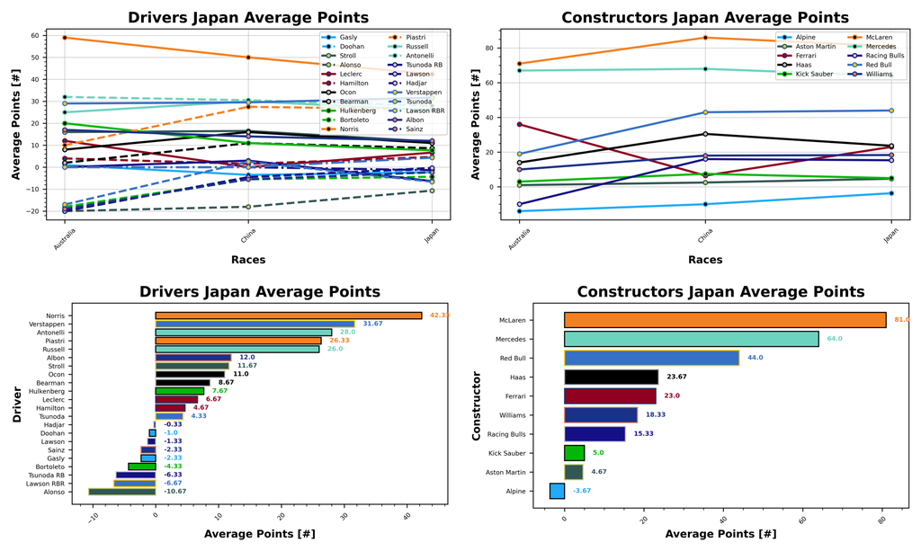

Mercedes top the Constructors' table this week with a points per value of 2.4 ppm, ahead of leaders McLaren with 2.32 ppm. Ferrari are back up in the top three with 2.07 ppm this week. Kick Sauber score a 0 this week, behind Alpine with 1.08 ppm. Haas round out the bottom three with 1.22 ppm.

ppm = points per million ($).

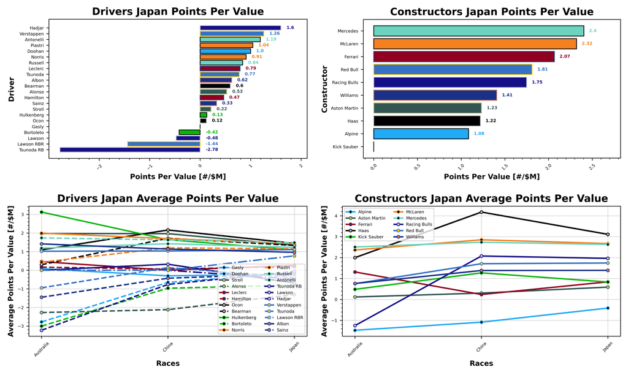

### Manager Scores

Now let's take a look at who came out on top this week. Rookie manager Alfie takes the victory this week with their team I Call Patrick Subaru, scoring an impressive 275 points. Chloe is in second with Mickeys Roadster Racers and 226 points, both of these managers making use of their tokens early in the season. In third place, it's another appearance for Alfie and Corona Wing Corn with 163 points. Sam is in fourth with Total F1 Performance bringing in 160 points, and Madlen rounds out the top five with Push, Push - Box Now Too and Wet Tyres Are Blue with 154 points. Down at the slow end, it's a third and final appearance from Alfie in this report, with their team cucumberpotatolamborghini scoring -55 points thanks to some penalties and a double inactive driver score. Then it's Valerie and Stroll To The 18th with 14 points, and their other teams Perez For World Champion and What Arrrgh Ya Doohan? with 20 and 23 points, respectively. Rounding out the bottom five is Patrick and Coming In Haast Place with 24 points.

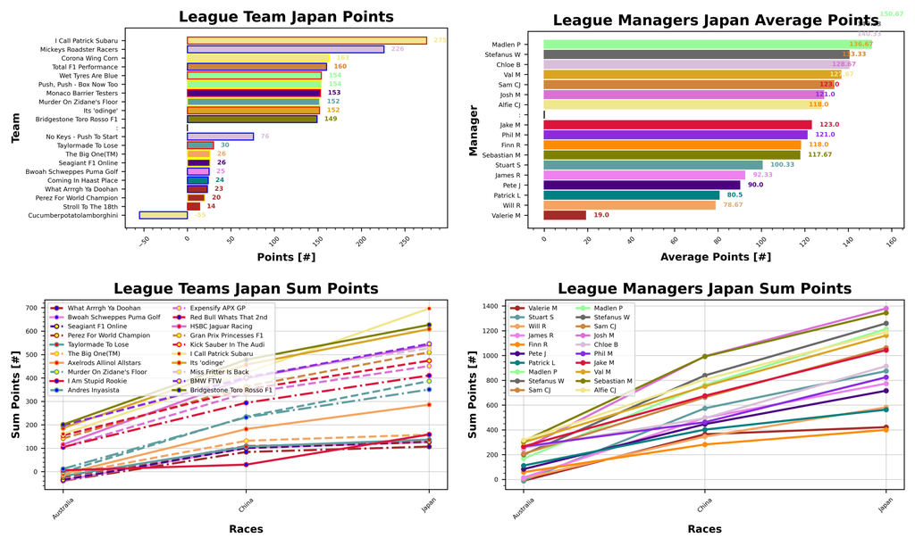

We have a new leader at the top of the table, rookie manager Alfie takes the lead with I Call Patrick Subaru and 697 points. Sebastian is in second with Bridgestone Toro Rosso F1 and 627 points. Then we have Val and Its 'odinge' with 609 points in third, ahead of Phil and BMW FTW in fourth with 546 points. Josh and HSBC Jaguar Racing rounds out the top five with 540 points. Valerie is now in last place with What Arrrgh Ya Doohan? sitting on 107 points, just behind Phil with BMW Should Be Here and 110 points. Then we have Alfie and cucumberpotatolamborghini with 122, tied with Val and Limoncello44. In fourth place, we have James and Bwoah Schweppes Puma Golf with 127, tied with Pete and Seagiant F1 Online. Rounding out the bottom five is Valerie and Perez For World Champion with 129 points.

Our biggest winner of the week is Chloe with Mickeys Roadster Racers jumping 14 places in the standings. Jake is the next big mover with I Am Stupid Rookie jumping 8 places. Phil and BMW Motorrad are in third with 7 places gained. Our biggest loser of the week is Alfie with Cucumberpotatolamborghini, dropping 16 places. Patrick is next with Coming In Haast Place dropping 10 places. Valerie rounds out the bottom three with What Arrrgh Ya Doohan? dropping 7 places.

Josh, Sebastian, and Stefanus lead the way in average manager points for the season, with 460, 448.33, and 420.0 points, respectively. Our worst manager of the year so far is Valerie with 140.67 points across their teams. Will is next with 194.0, and Pete rounds out the bottom three with 238.67. Our most penalised manager at the moment is Alfie who has taken 3 penalties with cucumberpotatolamborghini and 1 penalty with Corona Wing Corn. Plenty of managers getting caught out by the Tsunoda/Lawson problem this week.

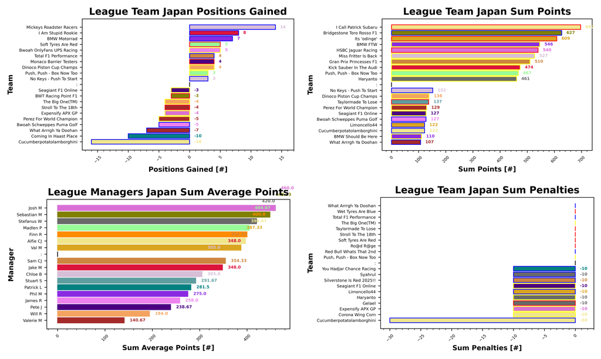

Isack Hadjar was your most selected driver this week, making it into your teams 24 times. Hulkenberg and Bearman next with 21 selections across your squads. Ocon is in third with 20 selections, so very popular Haas are this week. Bortoleto is in fourth place with 16 of you choosing the rookie. Oscar Piastri rounds out the top selected drivers with 14. Liam Lawson's Red Bull token is kicking around somewhere with 1 selection, Charles Leclerc is your least selected driver with 4. Tsunoda, Antonelli, and Verstappen are in third with 5 selections each. Then it's Lawson and Hamilton with 6, with Yuki Tsunoda's Racing Bulls token rounding out the bottom five with 7.

McLaren are your most selected team of the week with 15 of you choosing them for your squad, they're followed by Kick Sauber with 14 and Racing Bulls with 13. Aston Martin and Red Bull are your least selected this week, with only 5 of you choosing them. Williams and Alpine are next with 6 selections, and Mercedes round out the bottom three with 10 selections.

Lando Norris and Oscar Piastri are your two most boosted drivers this week, with the pair having 11 and 10, respectively, of you choosing to boost their scores. George Russell and Gabriel Bortoleto are in third with 4 selections. We only had four perks this week, 2 Wildcards and 2 Limitless.

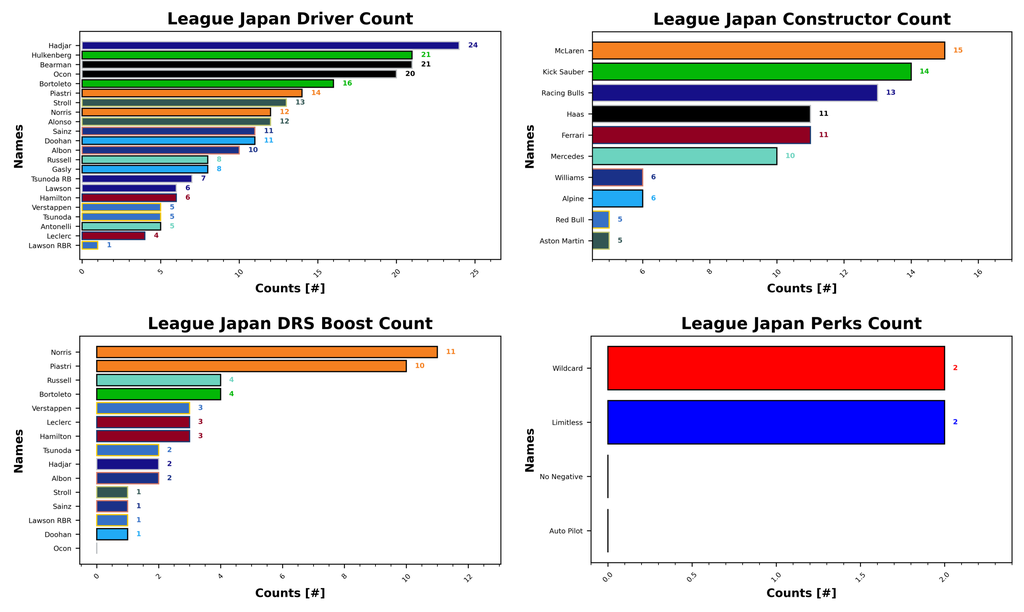

## Prizes

I have now updated the prizes plotting for my code and we should be able to track the season long prizes with ease. So without further adieu, let's take a look at what is currently in play this season.

### Championship

| Prize Name | Prize Value | Terms |
| --- | --- | --- |
|  | (%) |  |
| Champion of the World | 20 | Awarded to the top scorer in the league at the end of the season |
| If You're Not First, You're Last | 10 | Awarded to the second place scorer in the league at the end of the season |
| Alpine Podium | 5 | Awarded to the third place scorer in the league at the end of the season |
| Above Par | 20 | Awarded to the lowest scorer in the league at the end of the season, commonly referred to as the Golf League |

### Achievements

| Prize Name | Prize Value | Terms |
| --- | --- | --- |
|  | (%) |  |
| Cost Cappen | 5 | Highest average points per value at the end of the season |
| Sprint King | 5 | Highest score across the sprint races (China, Miami, Belgium, United States, Brazil, Qatar) |
| Flavio Controls Every Millimeter | 5 | Manager wide substitution count, highest wins |
| The Triple Header | 5 | Highest score across the triple header races (Japan, Bahrain, Saudi Arabia, Emilia Romagna, Monaco, Spain, Las Vegas, Qatar, Abu Dhabi) |
| I Forgot I Was Taking Part | 5 | Highest score in the first part of the season |
| Zak's Master Plan | 5 | Lowest score in the second half of the season |
| Mega Driver | 5 | Highest Extra DRS token score |
| The Continental | 5 | Highest score across all 5 continents, Mexico classed as South America for inclusion only (Australia, Canada, Great Britain, Azerbaijan, Mexico) |

### Spot Prizes

| Prize Name | Prize Value | Terms |
| --- | --- | --- |
|  | (%) |  |
| The Ring | 1 | Highest score at the Austrian Grand Prix |
| Bottas Bowling | 1 | Highest score at the Hungarian Grand Prix |
| Daniel's Broken Hand | 1 | Lowest score at the Netherlands Grand Prix |
| The Tifosi | 1 | Lowest score at the Italian Grand Prix |
| Go For The Gap | 1 | Lowest score at the Singapore Grand Prix |

### Spot Prizes

We haven't had a spot prize yet, I will post about it when we have one!

### Cost Cappen

Moving into the lead this week is Alfie, who takes a points per value of 2.34 ppm with I Call Patrick Subaru, ahead of Sebastian with Bridgestone Toro Rosso F1 with 2.1, and Val with Its 'odinge' with 2.05 ppm. This competition will run all year, but it's nice to keep a track of it.

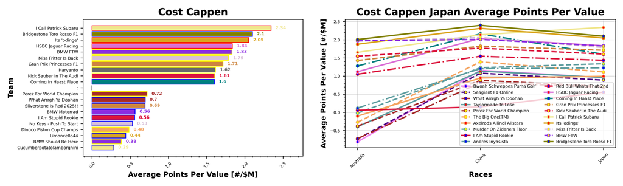

### Flavio Controls Every Millimeter

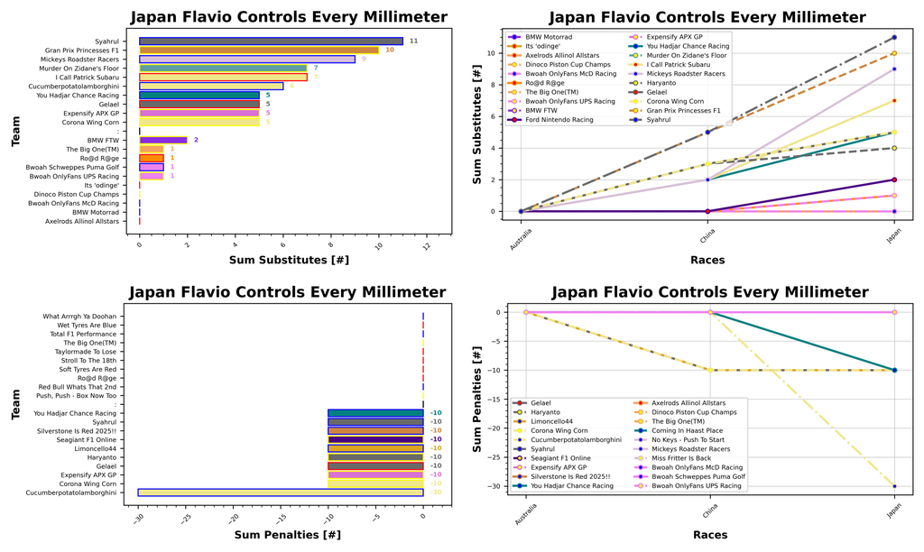

### Mega Driver

So far there have been no uses of the Extra DRS token. Check back later!

### Sprint King

Obviously no change to the Sprint King award this week. It's still Josh with HSBC Jaguar Racing out front with 283 points ahead of Sebastian and Bridgestone Toro Rosso F1 with 277 and Madlen with Push, Push - Box Now Too with 276.

```
No images found for Sprint King for Japan.
```

### The Continental

More To Come.

[output not shown]

### The Triple Header

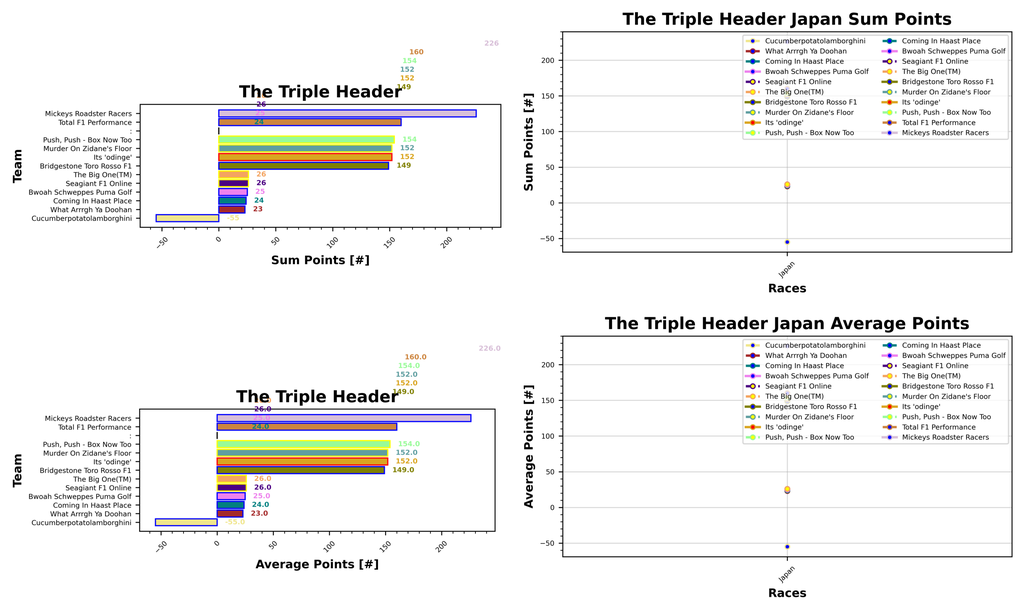

### I Forgot I Was Taking Part

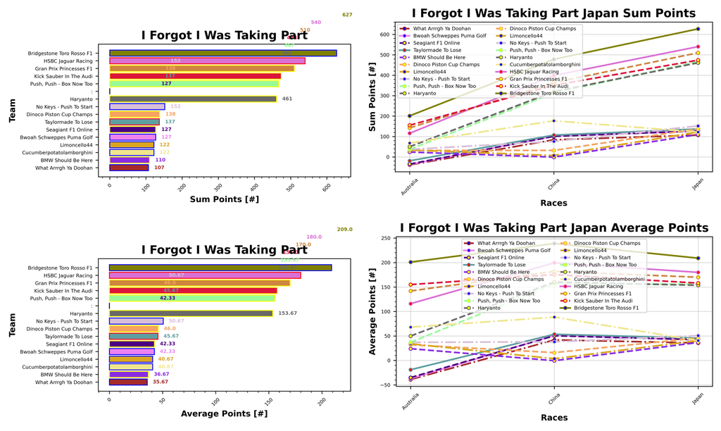

### Zak's Master Plan

Check back after the season break!

## F1 Predict

F1 predict time, I haven't quite yet sorted the plotting out for this one yet since I did my big overhaul middle of last year when everything started getting bit crazy, so bare with on the graphs for this one, I apologize. Val took the victory this week in Japan with 46 points. Phil was in second with 41 points, ahead of Josh in third with 15. The other three forgot to make predictions and scored 0.

## Next Up

Next up is the Bahrain GP, the second race in our first triple header. This one should be easier for overtaking, so keep your fingers crossed that we get a better race this weekend.